# Expression Quantitative Trait Loci

Dr Christopher Yau

17/10/2017

The human genome contains millions of locations (loci) called *single nucleotide polymorphisms* (SNPs pronouced “snips”) where the DNA sequence varies between individuals. As humans are *diploid* organisms, they have two *alleles* at each genetic locus, with one allele inherited from each parent. An *allele* is a variant of a gene.

Most SNPs are *biallelic* meaning that all individuals only have one of two DNA nucleotide types. For example, an A/T SNP means that individuals can have one of three genotypes (*AA*, *AT* or *TT*). A *genotype* is the set of alleles an individual possesses at a particular SNP.

In a *Mendelian Inheritence* model, a human child is assumed to inherit one allele from each of their two parents. Each parent gives a copy of *one* of their two alleles. For example, at an A/T SNP, your father might have genotype *AA* but your mother might have genotype *AT*. Your genotype must be *AA* or *AT* as your father can only give you an *A* but your mother can give you an *A* or *T*.

In a population of unrelated individuals, the minor allele is the variant that appears least often in the population (whilst the major refers to the most frequently occuring). The *minor allele frequency* (MAF) refers to the frequency that the minor allele occurs in the population.

If the MAF for a SNP with alleles $A$ and $a$ are denoted by $\theta$ then the probability that a randomly selected individual will have genotypes $AA$, $Aa$ or $aa$ are given as follows (think about flipping two coins):
$$\begin{align}
P( AA ) &= (1-\theta)^2, \\
P( Aa ) &= 2\theta(1-\theta) , \\
P( aa ) &= \theta^2 .
\end{align}$$
This model is based on the [Hardy-Weinberg Principle](https://en.wikipedia.org/wiki/Hardy%E2%80%93Weinberg_principle) which states that frequencies of alleles and genotypes will remain constant in the absence of any evolutionary forces.

An Expression Quantitative Trait Loci (eQTL) is a region in the genome where sequence variation can influence the expression level of one or more genes. We want to *discover* eQTLs by measuring genotypes at many SNPs, in many individuals and to identify if these associate with any changes in the level of gene expression for many genes.

Let $X_{ij} \in {0, 1, 2}$ denote the number of minor alleles in the genotype of the $i$-th individual at the $j$-th SNP. Let $Y_{ig}$ denote the expression level of the $g$-th gene for the $i$-th individual. We can use a linear model to relate the expression level to the genotype as follows:
$$Y_{ig} = a_j + b_j X_{ij} + \epsilon_{ij}$$
where $\epsilon_{ij} \sim N(0, \sigma_j^2)$, $a_j$ is the expression level for the genotype $AA$ (i.e. no minor alleles) and $b_j$ is the change in expression level with each additional copy of the minor allele.

Suppose now that we are only considering one gene and one SNP for the time being. Lets load some example data and plot it:

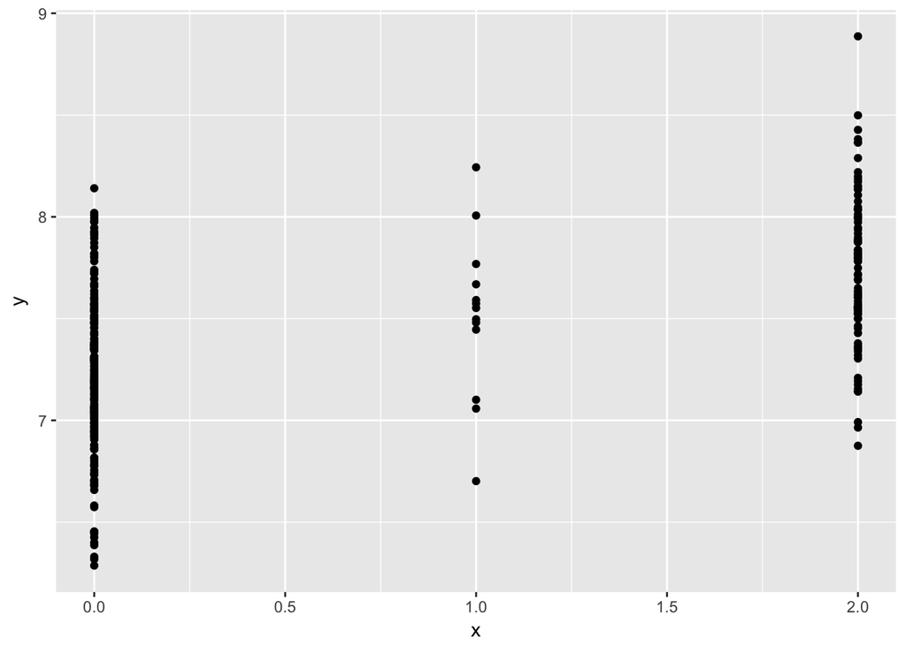

```r
library(ggplot2)
load("eqtl-ex1.Rdata")

one_snp_dat = data.frame(x=x, y=y) # create a data frame to store this data

plt = ggplot( one_snp_dat, aes(x=x, y=y)) + geom_point()
print(plt)
```

It seems as though when the number of minor alleles changes the expression level. Let us test this using a linear model:

```r
fit = lm(y~x, one_snp_dat) # fit linear model
summary(fit)
```

```
##
## Call:
## lm(formula = y ~ x, data = one_snp_dat)
##
## Residuals:
##      Min       1Q   Median       3Q      Max
## -0.93935 -0.22406  0.00556  0.25415  1.14333
##
## Coefficients:
##             Estimate Std. Error t value Pr(>|t|)
## (Intercept)  7.22596    0.02695  268.12   <2e-16 ***
## x            0.25883    0.02391   10.82   <2e-16 ***
## ---
## Signif. codes:  0 '***' 0.001 '**' 0.01 '*' 0.05 '.' 0.1 ' ' 1
##
## Residual standard error: 0.3794 on 298 degrees of freedom
## Multiple R-squared:  0.2822, Adjusted R-squared:  0.2798
## F-statistic: 117.1 on 1 and 298 DF,  p-value: < 2.2e-16
```

There seems to be a bit of a slope but lets compute a 95% confidence interval for the slope:

```r
confint(fit, level=0.95)
```

```
##                 2.5 %    97.5 %
## (Intercept) 7.1729255 7.2790003
## x           0.2117694 0.3058956
```

The confidence interval doesn’t contain zero which suggests that the genotype of this SNP does affect expression.

Now, lets scan across a genome-wide data set of 1,000 SNPs:

```r
load("eqtl-ex2.Rdata") # data set contains X and y

confidence_level = 0.95 # confidence interval level

n_snps = dim(X)[1] # number of SNPs
n = dim(X)[2] # number of individuals

lower_conf_int = rep(0, n_snps) # vector to store lower confidence interval limit
upper_conf_int = rep(0, n_snps) # vector to store upper confidence interval limit

# for each SNP
for ( j in 1:n_snps ) {
  dat = data.frame(x = X[j, ], y = y) # take data for a SNP
  fit_new = lm(y~x, dat) # fit linear model
  out = confint(fit_new, level=confidence_level) # get confidence interval
  lower_conf_int[j] = out[2, 1] # extract the lower limit
  upper_conf_int[j] = out[2, 2] # extract the upper limit
}
```

We have computed the confidence intervals for all 1,000 SNPs. Which intervals exclude zero?

```r
loc = which( ( lower_conf_int > 0 ) | ( upper_conf_int < 0) )
print(loc)
```

```
##  [1]   1  14  34  38  95 131 145 153 160 161 171 183 196 197 238 242 271
## [18] 311 352 363 364 376 381 394 415 417 432 434 524 532 550 552 556 560
## [35] 568 572 596 749 816 883 894 903 921 952 960 975 998
```

How many are there?

```r
print( length(loc) )
```

```
## [1] 47
```

Interesting, we set a confidence level of 95% and we get around 50 out of 1000 SNPs whose confidence intervals which exclude zero. Change the level to 80%. What happens?

This phenomenon is a result of **multiple testing** (or **multiple comparisons**). We are assessing each SNP individually to see if its slope parameter has a 95% confidence interval which excludes zero. Now, if all 1000 SNPs genuinely do not affect gene expression, they can be considered to be like repeated experiments. Therefore, at a confidence level of 95%, we can expect around 5% of those 1000 SNPs to yield intervals that do not cover zero by chance.

In order to have a confidence level which is suitable for multiple comparisons, one technique is to do a *Bonferroni Correction* and scale the confidence level by the number of comparisons being performed, i.e. use a level of $1-0.05/n$. The Bonferroni correction is ultra-conservative in the sense that it sets the confidence level high, forcing the confidence intervals to be large, many that even SNPs which genuinely do affect gene expression might not pass the association criteria.

# Simulating your own eQTL data

The examples above used data provided but it can be useful to simulate your own data to test various scenarios. Population geneticists do this all the time to try and understanding the characteristics of their statistical methods and the ability to pick up real biological associations (as well as the danger of detecting false ones!)

Lets see how we might generate some example data.

First, we know we have three possible genotypes for biallelic SNPs, so:

```r
genotypes = c(0., 1., 2.) # a vector of possible genotypes
```

Lets define how many SNPs and how many individuals we want to simulate data for (we will keep it simple by assuming we will generate expression data for only one gene):

```r
p = 200 # number of SNPs
n = 300 # number of individuals
```

We want to choose a minor allele frequency for each SNP. These values must be between 0 and 1. Let simulate these then from a standard uniform distribution on (0, 1):

```r
maf = runif(p) # vector of MAF
```

Now I need to work out the probability of each genotype for all the different SNPs which each have their own MAF (assuming the Hardy-Weinberg Principle):

```r
pr_genotypes = matrix( cbind( maf*maf, 2*(1-maf)*maf, (1-maf)*(1-maf) ), nrow=p, ncol=3, byrow=FALSE) # p x 3 matrix of genotype probabilities for each SNP
```

Now, lets simulate genotypes for my $n$ individuals at these $p$ SNPs:

```r
my_X = matrix(0, nrow=p, ncol=n)
for ( pi in 1:p ) {
  my_X[pi, ] = sample( genotypes, size = n, replace=TRUE, prob = pr_genotypes[pi, ] )
}
```

I now have a matrix of genotypes at $p$ SNPs for each of my $n$ individuals. We now need to simulate expression data to go with it.

We will need a single intercept term (the average gene expression level) but $p$ slope parameters to determine how each SNP affects the level of gene expression:

```r
sigma2 = 0.4^2 # noise variance (assume constant across SNPs)
a = rnorm(1, mean=7, sd=1) # intercept term
b = rnorm(p, mean=0, sd=0.1) # p slope parameters for each SNP
```

By using a small variance (standard deviation) for simulating the slope parameters we are assuming each SNP has a weak effect on the gene expression.

We can select one SNP to have *strong* effect. This is the *real* eQTL - the SNP that affects gene expression:

```r
b[145] = 3
```

Now simulate the gene expression data based on this eQTL:

```r
  e = rnorm(n, 0, sd=sqrt(sigma2))
  my_y = a + b[145]*my_X[145, ] + e
```

Use your simulated data `(my_X, my_y)` and re-run the linear regressions you did before. What does the confidence interval for SNP 145 look like compared to the others?

```r
confidence_level = 0.95 # confidence interval level

n_snps = dim(my_X)[1] # number of SNPs
n = dim(my_X)[2] # number of individuals

my_lower_conf_int = rep(0, p) # vector to store lower confidence interval limit
my_upper_conf_int = rep(0, p) # vector to store upper confidence interval limit

# for each SNP
for ( j in 1:p ) {
  dat = data.frame(x = my_X[j, ], y = my_y) # take data for a SNP
  fit_new = lm(y~x, dat) # fit linear model
  out = confint(fit_new, level=confidence_level) # get confidence interval
  my_lower_conf_int[j] = out[2, 1] # extract the lower limit
  my_upper_conf_int[j] = out[2, 2] # extract the upper limit
}
```

Lets plot it:

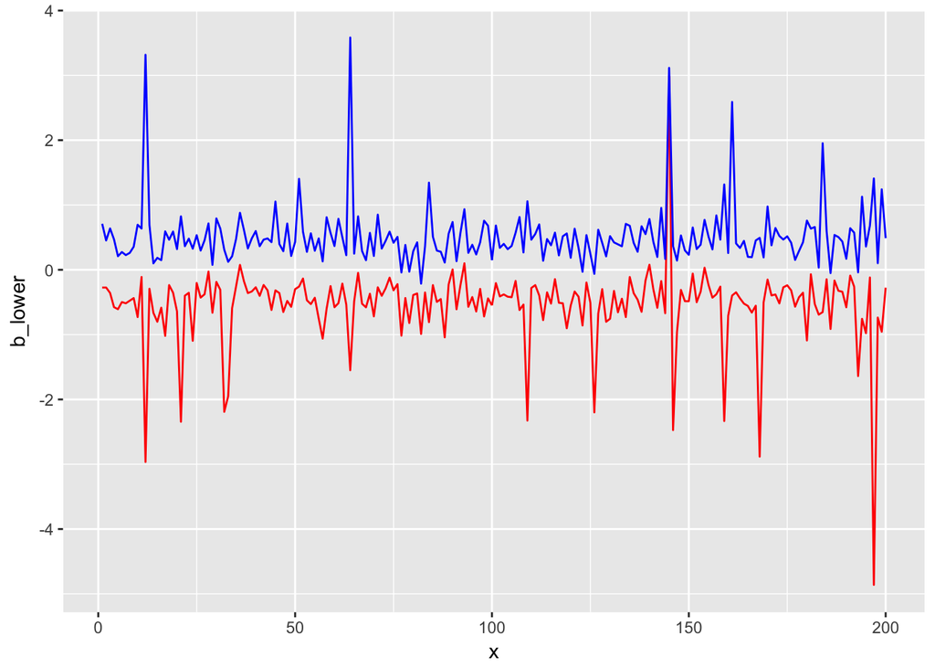

```r
my_dat = data.frame(x=c(1:p), b_lower = my_lower_conf_int, b_upper = my_upper_conf_int)

plt = ggplot(my_dat)
plt = plt + geom_line(aes(x=x, y=b_lower), colour='red' )
plt = plt + geom_line(aes(x=x, y=b_upper), colour='blue' )
print(plt)
```

And how many SNPs have confidence intervals for $b$ which do not cover zero:

```r
loc = which( ( my_lower_conf_int > 0 ) | ( my_upper_conf_int < 0) )
print(loc)
```

```
##  [1]  36  77  79  82  90  93 123 126 140 145 154 186 193
```

Try changing the confidence level and using the Bonferroni correction to see what happens.